# Estudis d'Informàtica, Multimédia i Telecomunicacions

# Tipología y Ciclo de Vida de los Datos: Práctica 2

Autor: Roberto Díaz Badra

Enero 2019

# 1 Realización

## 1.1 Descripción del dataset

El conjunto de datos a analizar ha sido obtenido a partir de la página de Kaggle(https://www.kaggle.com/c/titanic/data). El 15 de abril de 1912, durante su viaje inaugural, el Titanic se hundió tras colisionar con un iceberg, matando a 1502 de los 2224 pasajeros y tripulación. Esta tragedia, sacudió a la comunidad internacional y condujo a mejores regulaciones de seguridad para barcos.

Una de las razones que produjeron tantas muertes, fue la falta de botes salvavidas para todos los pasajeros y la tripulación. Aunque hubo algún elemento de suerte a la hora de sobrevivir al hundimiento, habían algunos grupos de personas con más probabilidad de sobrevivir que otros, como mujeres, niños y la clase alta.

Nuestro conjunto de datos, posee información sobre diversos pasajeros del Titanic, entre ellos si la persona sobrevivió o no.

Este dataset está compuetso por 12 columnas y 891 instancias. Entre los campos, se encuentran los siguientes:

- **PassengerId**: Id de los pasajeros.
- **Survived**: Campo que indica si el pasajero sobrevivió o no.
- **Pclass**: Estado socio económico de los pasajeros; 1 = Clase Alta, 2 = Clase Media, 3 = Clase Baja.
- **Name**: Nombre de los pasajeros.
- **Sex**: Sexo de los pasajeros.
- **Age**: Edad en años de los pasajeros. Esta fraccionada en la forma xx.5 si es menor de 1.
- **SibSp**: Número de hermanos o cónyuges en el Titanic.
- **Parch**: Número de padres o hijos en el Titanic.
- **Ticket**: Número del ticket.
- **Fare**: Precio del viaje.
- **Cabin**: Número de cabina.
- **Embarked**: Puerto en el que embarcó. C = Cherbourg, Q = Queenstown, S = Southampton.

## 1.2 Importancia del dataset

Este conjunto de datos representa un conjunto de pasajeros que estuvieron en el hundimiento del Titanic. Con este proyecto, se pretende identificar si hubo alguna variable que influyó de manera notable en que algunos pasajeros sobrevivieran.

Mediante este análisis, se podrá llegar a realizar un modelo de clasificación, que mediante los datos de un pasajero, pudiera predecir si este sobreviviera o no al hundimiento del Titanic. De este algoritmo, se podría llegar a obtener conclusiones relevantes, que permitieran a una persona en un futuro tomar decisiones acertadas, para preveer el mejor desenlace en caso de catástrofe.

## 1.3 Limpieza de los datos

```r
# Lectura de datos
titanic <- read.table(file="../data/train.csv", header=TRUE, sep=",")

# Observamos la estructura del conjunto de datos
str(titanic)
```

```
## 'data.frame':    891 obs. of  12 variables:
##  $ PassengerId: int  1 2 3 4 5 6 7 8 9 10 ...
##  $ Survived   : int  0 1 1 1 0 0 0 0 1 1 ...
##  $ Pclass     : int  3 1 3 1 3 3 1 3 3 2 ...
##  $ Name       : Factor w/ 891 levels "Abbing, Mr. Anthony",..: 109 191 358 277 16 559 520 629 417 581 ...
##  $ Sex        : Factor w/ 2 levels "female","male": 2 1 1 1 2 2 2 2 1 1 ...
##  $ Age        : num  22 38 26 35 35 NA 54 2 27 14 ...
##  $ SibSp      : int  1 1 0 1 0 0 0 3 0 1 ...
##  $ Parch      : int  0 0 0 0 0 0 0 1 2 0 ...
##  $ Ticket     : Factor w/ 681 levels "110152","110413",..: 524 597 670 50 473 276 86 396 345 133 ...
##  $ Fare       : num  7.25 71.28 7.92 53.1 8.05 ...
##  $ Cabin      : Factor w/ 148 levels "","A10","A14",..: 1 83 1 57 1 1 131 1 1 1 ...
##  $ Embarked   : Factor w/ 4 levels "","C","Q","S": 4 2 4 4 4 3 4 4 4 2 ...
```

```r
head(titanic)
```

```
##   PassengerId Survived Pclass
## 1           1        0      3
## 2           2        1      1
## 3           3        1      3
## 4           4        1      1
## 5           5        0      3
## 6           6        0      3
##                                                  Name    Sex Age SibSp
## 1                             Braund, Mr. Owen Harris   male  22     1
## 2 Cumings, Mrs. John Bradley (Florence Briggs Thayer) female  38     1
## 3                              Heikkinen, Miss. Laina female  26     0
## 4        Futrelle, Mrs. Jacques Heath (Lily May Peel) female  35     1
## 5                            Allen, Mr. William Henry   male  35     0
## 6                                    Moran, Mr. James   male  NA     0
##   Parch           Ticket    Fare Cabin Embarked
## 1     0        A/5 21171  7.2500              S
## 2     0         PC 17599 71.2833   C85        C
## 3     0 STON/O2. 3101282  7.9250              S
## 4     0           113803 53.1000  C123        S
## 5     0           373450  8.0500              S
## 6     0           330877  8.4583              Q
```

```r
# Tipo de dato de cada campo
sapply(titanic, function(x) class(x))
```

```
## PassengerId    Survived      Pclass        Name         Sex         Age
##   "integer"   "integer"   "integer"    "factor"    "factor"   "numeric"
##       SibSp       Parch      Ticket        Fare       Cabin    Embarked
##   "integer"   "integer"    "factor"   "numeric"    "factor"    "factor"
```

Factorizamos los campos “Survived”, “Pclass”, “SibSp” y “Parch”, ya que solo toman un conjunto de valores definidos, en lugar de tener valores numéricos, los cuales pueden obtener un conjunto infinito de valores.

```r
cols <- c("Survived", "Pclass", "SibSp", "Parch")
for (i in cols){
  titanic[,i] <- as.factor(titanic[,i])
}
str(titanic)
```

```
## 'data.frame':    891 obs. of  12 variables:
##  $ PassengerId: int  1 2 3 4 5 6 7 8 9 10 ...
##  $ Survived   : Factor w/ 2 levels "0","1": 1 2 2 2 1 1 1 1 2 2 ...
##  $ Pclass     : Factor w/ 3 levels "1","2","3": 3 1 3 1 3 3 1 3 3 2 ...
##  $ Name       : Factor w/ 891 levels "Abbing, Mr. Anthony",..: 109 191 358 277 16 559 520 629 417 581 ...
##  $ Sex        : Factor w/ 2 levels "female","male": 2 1 1 1 2 2 2 2 1 1 ...
##  $ Age        : num  22 38 26 35 35 NA 54 2 27 14 ...
##  $ SibSp      : Factor w/ 7 levels "0","1","2","3",..: 2 2 1 2 1 1 1 4 1 2 ...
##  $ Parch      : Factor w/ 7 levels "0","1","2","3",..: 1 1 1 1 1 1 1 2 3 1 ...
##  $ Ticket     : Factor w/ 681 levels "110152","110413",..: 524 597 670 50 473 276 86 396 345 133 ...
##  $ Fare       : num  7.25 71.28 7.92 53.1 8.05 ...
##  $ Cabin      : Factor w/ 148 levels "","A10","A14",..: 1 83 1 57 1 1 131 1 1 1 ...
##  $ Embarked   : Factor w/ 4 levels "","C","Q","S": 4 2 4 4 4 3 4 4 4 2 ...
```

### 1.3.1 Gestión de elementos vacíos

```r
sapply(titanic, function(x) sum(is.na(x)))
```

```
## PassengerId    Survived      Pclass        Name         Sex         Age
##           0           0           0           0           0         177
##       SibSp       Parch      Ticket        Fare       Cabin    Embarked
##           0           0           0           0           0           0
```

```r
colSums(titanic=="")
```

```
## PassengerId    Survived      Pclass        Name         Sex         Age
##           0           0           0           0           0          NA
##       SibSp       Parch      Ticket        Fare       Cabin    Embarked
##           0           0           0           0         687           2
```

Ya que el campo “Age” tiene gran cantidad de elementos vacíos, en los que R ha insertado un “NA”, optamos por modificar estos valores nulos, aplicando el método KNN.

```r
library(VIM)
titanic$Age[is.na(titanic$Age)] <- kNN(titanic)$Age
```

Mostramos en un histograma los valores más comunes para el campo “Embarked”.

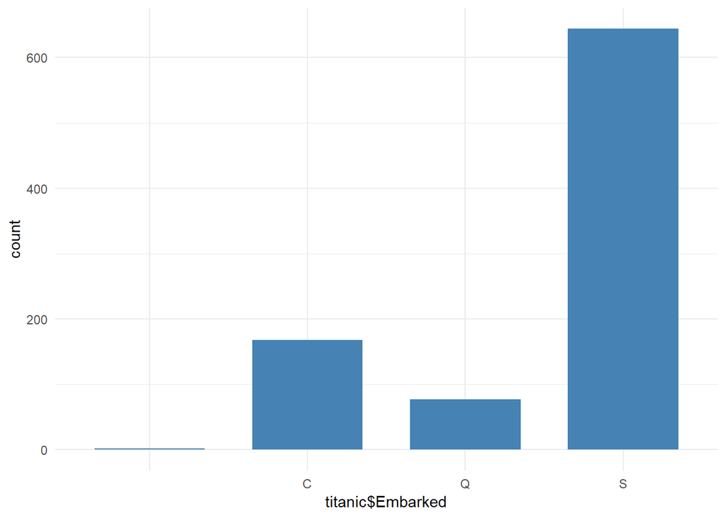

```r
library(ggplot2)
ggplot(titanic, aes(x=titanic$Embarked))+
  geom_bar(stat="count", width=0.7, fill="steelblue")+
  theme_minimal()
```

Llevamos a cabo el mismo procedimiento para el campo Embarked que para Age y volvemos a dibujar una gráfica para ver la distribución de elementos.

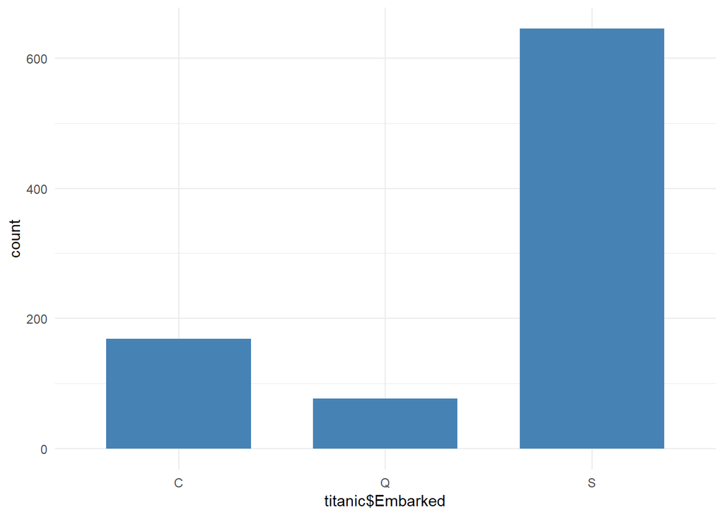

```r
titanic$Embarked[titanic$Embarked==""] <- kNN(titanic)$Embarked
ggplot(titanic, aes(x=titanic$Embarked))+
  geom_bar(stat="count", width=0.7, fill="steelblue")+
  theme_minimal()
```

### 1.3.2 Identificación y tratamiento de valores extremos

Mostramos en una gráfica de dispersión las tarifas que pagaron los pasajeros del Titanic. Observamos que hay 3 que parecen ser valores extremos.

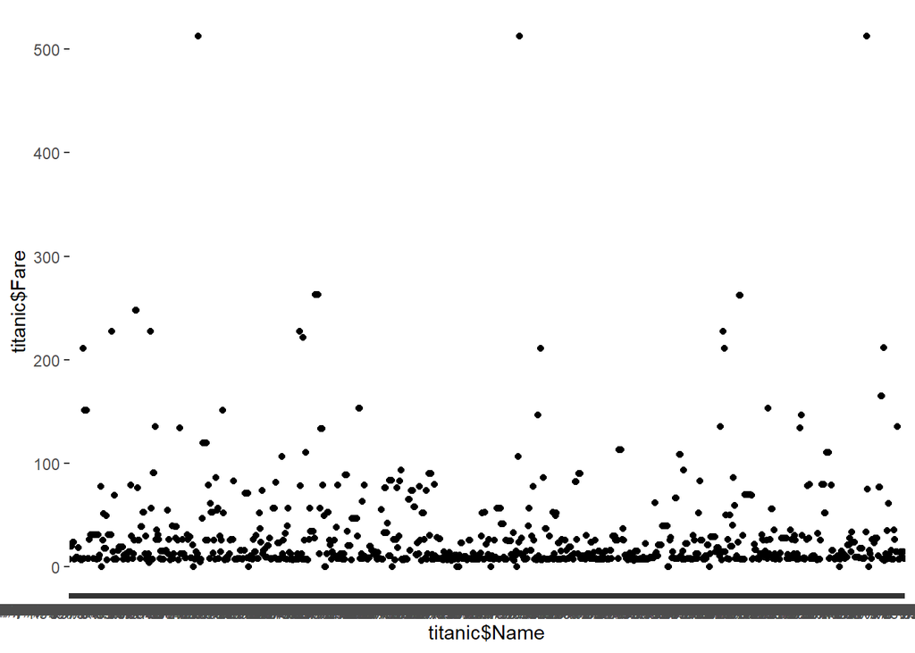

```r
ggplot(titanic, aes(x=titanic$Name, y=titanic$Fare)) + geom_point()
```

Creamos una nueva gráfica filtrando por el estado socio económico de los pasajeros, ya que podemos observar que hay elementos que tienen valores mucho más elevados que la media y observamos que estos valores elevados, son de pasajeros de primera clase, por lo que podríamos pensar que son valores correctos. Así que no los eliminaremos.

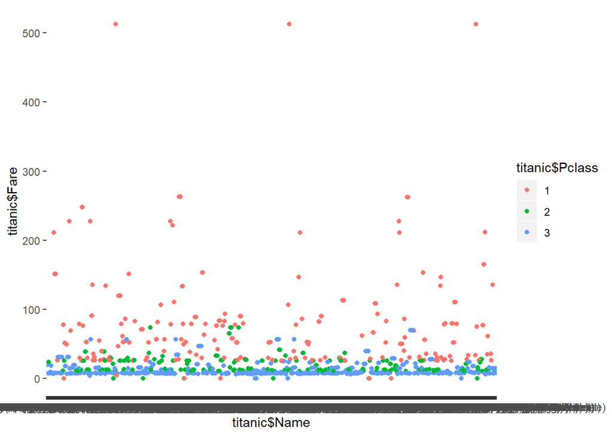

```r
ggplot(titanic, aes(x=titanic$Name, y=titanic$Fare, color=titanic$Pclass)) + geom_point()
```

Mostramos en una nueva gráfica de dispersión todas las edades de los pasajeros en busca de elementos extremos, filtrando por el estado socio económico de los pasajeros. Como se puede observar, parece que todos siguen la misma distribución y además están en un rango posible de valores, al tener la persona con mayor edad unos 80 años, por lo que no será necesario eliminar ningún elemento.

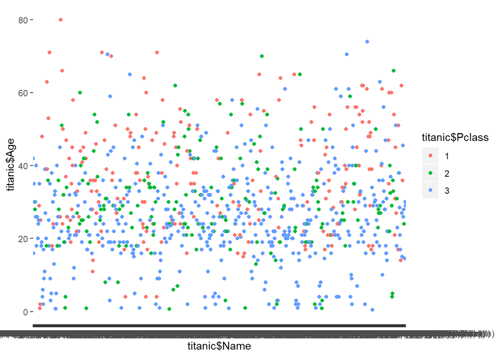

```r
ggplot(titanic, aes(x=titanic$Name, y=titanic$Age, color=titanic$Pclass)) + geom_point()
```

### 1.3.3 Integración y selección de los datos de interés a analizar

Como hemos visto previamente, de 891 registros que tiene el conjunto de datos, el campo “Cabin” tiene más de 600 elementos vacíos, por lo que es un campo que no aporta gran valor y no tendría sentido estimar unos posibles valores, por ello lo eliminaremos. Eliminaremos también los campos “Name” y “Ticket” ya que simplemente nos aportan datos que no deberían tener ninguna relevancia a la hora de ayudarnos a generar relaciones, ya que simplemente nos indican identificadores únicos o nombres que no pueden generar patrones. Almacenaremos el campo “PassengerId” para ejercicios de evaluación, pero será omitido durante los análisis.

```r
titanic$Cabin <- NULL
titanic$Name <- NULL
titanic$Ticket <- NULL
str(titanic)
```

```
## 'data.frame':    891 obs. of  9 variables:
##  $ PassengerId: int  1 2 3 4 5 6 7 8 9 10 ...
##  $ Survived   : Factor w/ 2 levels "0","1": 1 2 2 2 1 1 1 1 2 2 ...
##  $ Pclass     : Factor w/ 3 levels "1","2","3": 3 1 3 1 3 3 1 3 3 2 ...
##  $ Sex        : Factor w/ 2 levels "female","male": 2 1 1 1 2 2 2 2 1 1 ...
##  $ Age        : num  22 38 26 35 35 22 54 2 27 14 ...
##  $ SibSp      : Factor w/ 7 levels "0","1","2","3",..: 2 2 1 2 1 1 1 4 1 2 ...
##  $ Parch      : Factor w/ 7 levels "0","1","2","3",..: 1 1 1 1 1 1 1 2 3 1 ...
##  $ Fare       : num  7.25 71.28 7.92 53.1 8.05 ...
##  $ Embarked   : Factor w/ 4 levels "","C","Q","S": 4 2 4 4 4 3 4 4 4 2 ...
```

### 1.3.4 Almacenamiento del CSV final

Una vez finalizados todos los procedimientos de limpieza de datos, realizados sobre el conjunto de datos inicial, procedemos a almacenar este conjunto de datos final en un nuevo archivo en formato CSV.

```r
write.csv(titanic, "../data/titanic_final.csv")
titanic$PassengerId <- NULL
```

## 1.4 Análisis de los datos

### 1.4.1 Selección de grupos de datos a analizar

Para el análisis, se utilizarán aquellas variables que se han escogido hasta ahora, puetso que hemos hecho una limpieza previa de aquellos campos que no resultarían interesantes.

### 1.4.2 Comprobación de la normalidad y homogeneidad de la varianza

#### 1.4.2.1 Análisis de normalidad

Comprobamos si las variables cuantitativas siguen una distribución normal. Para ello llevaremos a cabo varias pruebas de normalidad. Se tomarán en cuenta las siguientes hipótesis:

H0: La muestra proviene de una distribución normal.

H1: La muestra no proviene de una distribución normal.

El nivel de significancia con que se trabajará es de 0.05. Alfa = 0.05

Criterio de Decisión

Si P < Alfa Se rechaza Ho

Si p >= Alfa No se rechaza Ho

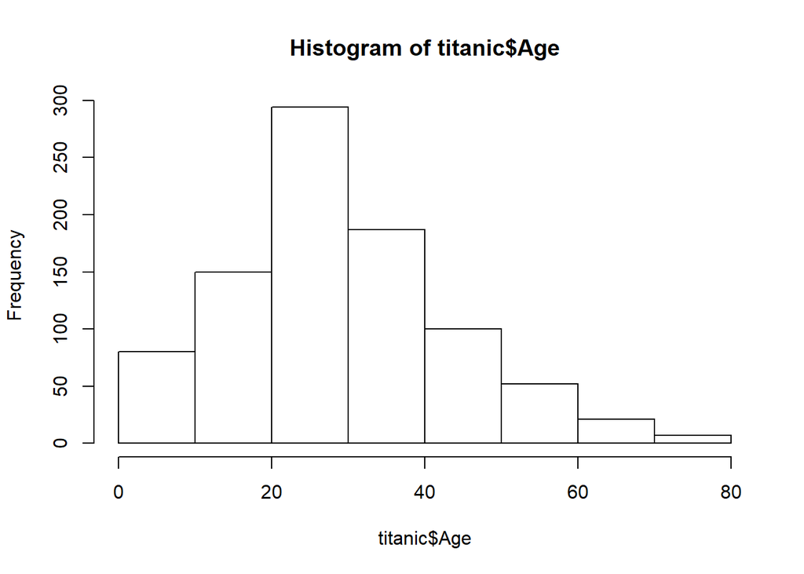

```r
library(normtest)

hist(titanic$Age)
```

```r
jb.norm.test(titanic$Age)
```

```
##
##  Jarque-Bera test for normality
##
## data:  titanic$Age
## JB = 29.504, p-value < 2.2e-16
```

```r
frosini.norm.test(titanic$Age)
```

```
##
##  Frosini test for normality
##
## data:  titanic$Age
## B = 0.83831, p-value < 2.2e-16
```

```r
shapiro.test(titanic$Age)
```

```
##
##  Shapiro-Wilk normality test
##
## data:  titanic$Age
## W = 0.9787, p-value = 4.023e-10
```

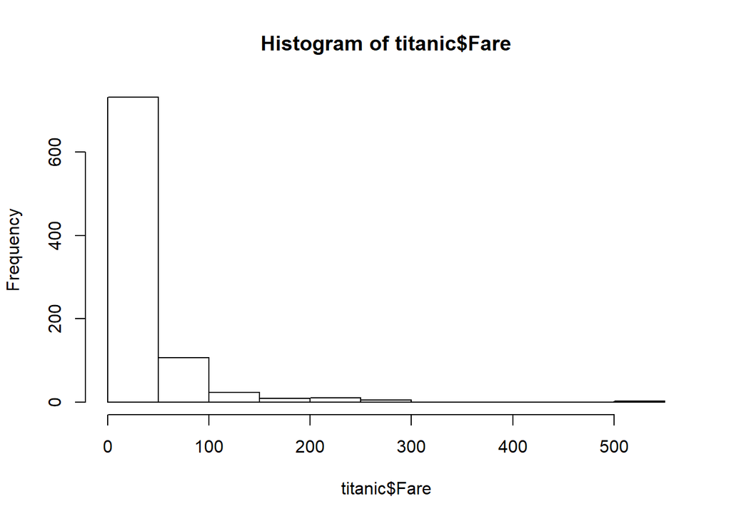

```r
hist(titanic$Fare)
```

```r
jb.norm.test(titanic$Fare)
```

```
##
##  Jarque-Bera test for normality
##
## data:  titanic$Fare
## JB = 44323, p-value < 2.2e-16
```

```r
frosini.norm.test(titanic$Fare)
```

```
##
##  Frosini test for normality
##
## data:  titanic$Fare
## B = 4.2277, p-value < 2.2e-16
```

```r
shapiro.test(titanic$Fare)
```

```
##
##  Shapiro-Wilk normality test
##
## data:  titanic$Fare
## W = 0.52189, p-value < 2.2e-16
```

Como todos los resultador tienen un p-value menor de 0.05, se puede afirmar que estos dos campos no siguen una distribución normal.

#### 1.4.2.2 Análisis de la homogeneidad de la varianza

A continuación pasamos al estudio de la homogeneidad de la varianza. Teniendo en cuenta que nuestras variables cuantitativas no siguen una sitribución normal, llevaremos a cabo el test Fligner-Killeen. Llevaremos a cabo este test para grupos de hombres y mujeres con sus respectivas edades.

```r
fligner.test(Age~Sex, data=titanic)
```

```
##
##  Fligner-Killeen test of homogeneity of variances
##
## data:  Age by Sex
## Fligner-Killeen:med chi-squared = 0.016552, df = 1, p-value =
## 0.8976
```

Al ser el p-value mayor de 0.05, aceptamos la hipótesis de que las varianzas de las muestras son homogéneas.

Ahora lo llevaremos a cabo para los grupos de hombres y mujeres con las respectivas tarifas que pagaron para ser pasajeros del Titanic.

```r
fligner.test(Fare~Sex, data=titanic)
```

```
##
##  Fligner-Killeen test of homogeneity of variances
##
## data:  Fare by Sex
## Fligner-Killeen:med chi-squared = 55.949, df = 1, p-value =
## 7.436e-14
```

Al ser el p-value menor de 0.05, se rechaza la hipótesis de que las varianzas de las muestras son homogéneas.

### 1.4.3 Aplicación de pruebas estadísticas

#### 1.4.3.1 Análisis de correlación

Llevaremos a cabo una análisis de correlaciones para poder deducir que variables tienen mayor influencia sobre el hecho de si un pasajero sobrevivió o no al Titanic utilizando para ello el test de Pearson Chi cuadrado.

```r
cols <- colnames(titanic)
cols <- cols[-1]
cols
```

```
## [1] "Pclass"   "Sex"      "Age"      "SibSp"    "Parch"    "Fare"
## [7] "Embarked"
```

```r
matrix <- matrix(nc=1, nr=0)
for (i in cols){
  chi = chisq.test(titanic[,i], titanic$Survived, correct = FALSE)
  matrix <- rbind(matrix, chi[3])
  rownames(matrix)[nrow(matrix)] <- i
}
matrix
```

```
##          p.value
## Pclass   4.549252e-23
## Sex      3.711748e-59
## Age      0.06462806
## SibSp    1.558581e-06
## Parch    9.703526e-05
## Fare     1.164764e-11
## Embarked 1.386837e-06
```

Por lo que podemos observar en la matriz anterior, aquellos elementos con p-value menor de 0.05 tienen una fuerte correlación con la supervivencia o no del Titanic. Por lo tanto, el único campo que parece no tener relevancia alguna es “Age”, ya que tiene un valor mayor de 0.05. Por otro lado, el campo con mayor relevancia parece haber sido “Sex”.

#### 1.4.3.2 Contraste de hipótesis

A continuación se realizará otra prueba estadística para determinar si aquellos pasajeros que pagaron más por su ticket, tenían más posibilidades de sobrevivir.

Para ello tendremos dos muestras, una reflejando el precio del ticket de aquellas personas que sobrevivieron y otra de aquellas que no sobrevivieron. Para esto utilizamos el test de Wilcoxon-Mann-Whitney, el cual contrasta si dos muestras proceden de la misma distribución o si, por el contrario, una de ellas tiende a producir valores más altos que la otra. Suele utilizarse como alternativa no paramétrica al t-test, cuando no se dan las condiciones de normalidad en las variables, como es nuestro caso.

```r
titanic.survived.fare <- titanic[titanic$Survived == "1",]$Fare
titanic.notSurvived.fare <- titanic[titanic$Survived == "0",]$Fare

wilcox.test(titanic.survived.fare, titanic.notSurvived.fare, alternative="less")
```

```
##
##  Wilcoxon rank sum test with continuity correction
##
## data:  titanic.survived.fare and titanic.notSurvived.fare
## W = 129950, p-value = 1
## alternative hypothesis: true location shift is less than 0
```

#### 1.4.3.3 Regresión Logística

Como se expuso al principio, el objetivo de este estudio era la capacidad de llevar a cabo un algoritmo predictivo que permitiera inferir si un pasajero dada unas determinadas condiciones sobreviviría o no al hundimiento del Titanic. Por eso, teniendo en cuenta que se trata de un problema de clasificación binaria, se emplea una regresión logística.

En primer lugar, se divide el conjunto de datos en uno de entrenamiento y otro de evaluación. Entrenamos la regresión logística con el conjunto de entrenamiento

```r
train <- titanic[1:800,]
test <- titanic[801:891,]
model <- glm(Survived ~.,family=binomial(link='logit'),data=train)
summary(model)
```

```
##
## Call:
## glm(formula = Survived ~ ., family = binomial(link = "logit"),
##     data = train)
##
## Deviance Residuals:
##     Min       1Q   Median       3Q      Max
## -2.7602  -0.6240  -0.4038   0.6090   2.4289
##
## Coefficients:
##               Estimate Std. Error z value Pr(>|z|)
## (Intercept)  3.554e+00  5.059e-01   7.024 2.16e-12 ***
## Pclass2     -9.393e-01  3.212e-01  -2.925  0.00345 **
## Pclass3     -2.064e+00  3.229e-01  -6.393 1.63e-10 ***
## Sexmale     -2.724e+00  2.152e-01 -12.655  < 2e-16 ***
## Age         -3.313e-02  7.936e-03  -4.174 2.99e-05 ***
## SibSp1       1.251e-01  2.352e-01   0.532  0.59474
## SibSp2      -1.556e-01  5.301e-01  -0.293  0.76916
## SibSp3      -2.205e+00  7.248e-01  -3.042  0.00235 **
## SibSp4      -1.287e+00  7.984e-01  -1.612  0.10696
## SibSp5      -1.593e+01  9.532e+02  -0.017  0.98666
## SibSp8      -1.569e+01  9.322e+02  -0.017  0.98657
## Parch1       2.135e-01  3.081e-01   0.693  0.48839
## Parch2       5.536e-02  3.921e-01   0.141  0.88773
## Parch3      -1.828e-01  1.187e+00  -0.154  0.87760
## Parch4      -1.601e+01  1.053e+03  -0.015  0.98786
## Parch5      -8.942e-01  1.237e+00  -0.723  0.46990
## Parch6      -1.666e+01  2.400e+03  -0.007  0.99446
## Fare         2.021e-03  2.467e-03   0.819  0.41283
## EmbarkedQ    4.708e-02  4.057e-01   0.116  0.90763
## EmbarkedS   -1.873e-01  2.612e-01  -0.717  0.47329
## ---
## Signif. codes:  0 '***' 0.001 '**' 0.01 '*' 0.05 '.' 0.1 ' ' 1
##
## (Dispersion parameter for binomial family taken to be 1)
##
##     Null deviance: 1066.33  on 799  degrees of freedom
## Residual deviance:  691.02  on 780  degrees of freedom
## AIC: 731.02
##
## Number of Fisher Scoring iterations: 15
```

```r
anova(model, test="Chisq")
```

```
## Analysis of Deviance Table
##
## Model: binomial, link: logit
##
## Response: Survived
##
## Terms added sequentially (first to last)
##
##
##          Df Deviance Resid. Df Resid. Dev  Pr(>Chi)
## NULL                       799    1066.33
## Pclass    2   86.730       797     979.60 < 2.2e-16 ***
## Sex       1  238.633       796     740.97 < 2.2e-16 ***
## Age       1   20.851       795     720.12 4.963e-06 ***
## SibSp     6   20.552       789     699.57  0.002207 **
## Parch     6    6.747       783     692.82  0.344890
## Fare      1    0.961       782     691.86  0.326991
## Embarked  2    0.841       780     691.02  0.656694
## ---
## Signif. codes:  0 '***' 0.001 '**' 0.01 '*' 0.05 '.' 0.1 ' ' 1
```

A partir de esta regresión logística, se puede observar que las variables “Parch”, “Fare” y “Embarked” aportan muy poco o nada a la hora de predecir. Como se puede observar, cuando la variable “Sex” tiene valor “male”, es decir cuando los pasajeros son hombres, tienen menos posibilidades de sobrevivir que si fueran mujeres.

Por último evaluamos el modelo con el conjunto de evaluación, dando un precisión de 82%, la cual es un porcentaje bastante decente.

```r
fitted.results <- predict(model,newdata=subset(test),type='response')
fitted.results <- ifelse(fitted.results > 0.5,1,0)
misClasificError <- mean(fitted.results != test$Survived)
print(paste('Accuracy',1-misClasificError))
```

```
## [1] "Accuracy 0.824175824175824"
```

## 1.5 Representación de los resultados a partir de tablas y gráficas

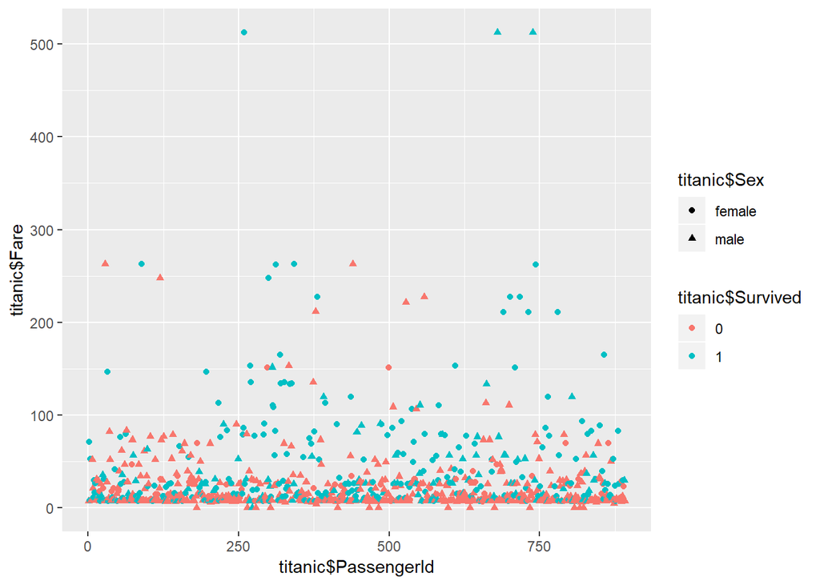

```r
titanic <- read.table(file="../data/titanic_final.csv", header=TRUE, sep=",")
titanic$X <- NULL
cols <- c("Survived", "Pclass", "SibSp", "Parch")
for (i in cols){
  titanic[,i] <- as.factor(titanic[,i])
}
ggplot(titanic, aes(x=titanic$PassengerId, y=titanic$Fare, color=titanic$Survived, shape=titanic$Sex)) + geom_point()
```

```r
# Tabla de contingencia mostrando número de personas que sobrevivieron por estado socio económico
table(titanic$Survived, titanic$Pclass)
```

```
##
##       1   2   3
##   0  80  97 372
##   1 136  87 119
```

```r
# Tabla de contingencia mostrando número de personas que sobrevivieron por sexo
table(titanic$Survived, titanic$Sex)
```

```
##
##     female male
##   0     81  468
##   1    233  109
```

## 1.6 Conclusiones

A partir del análisis realizado, se puede deducir que las variables que más influyen en la supervivencia de un pasajero del Titanic son el sexo y el estado socio económico. Como se dijo en un principio, el estado económico de una persona era muy relevante, ya que la mayor cantidad de pasajeros que murieron pertenecían a la tercera clase. También se puede observar que si una persona era mujer tenía mas probabilidades de sobrevivir.

Por todos esto, se puede llegar a la conclusión de que el análisis realizado ha sido lo bastante eficiente como para poder llegar a realizar deducciones a partir de estos datos, no solo esto, sino que como se demostró en el apartado anterior, es completamente posible la generación de un modelo de clasifiación, que permite llevar a cabo una predicción con un buen porcentaje de precisión.

## 1.7 Código

El código ejecutado en este proyecto se puede encontrar en el siguiente enlace [link](https://github.com/rdbadra/Kaggle-Titanic)